# Analiza podataka blockchain trgovačkog lanca primjenom Apache Spark i mašinskog učenja

Analiza podataka i predikcija statusa narudžbi

Mili Bovan

23. June 2026

# 1 Uvod

Ovaj rad prezentuje sveobuhvatnu analizu podataka generisanih u okviru blockchain platforme za upravljanje trgovačkim lancem (*Hyperledger Commerce Chain*). Osnovna motivacija istraživanja leži u potrebi za dubokim razumijevanjem ponašanja korisnika, karakteristika narudžbi i performansi različitih tipova trgovaca u decentralizovanom okruženju.

Analiza obuhvata nekoliko ključnih faza: učitavanje i inspekciju sirovih podataka, čišćenje i pripremu podataka, eksploratornu analizu sa vizualizacijom, inženjering karakteristika, te primjenu algoritama mašinskog učenja u cilju klasifikacije statusa narudžbi i segmentacije korisnika. Svi koraci su implementirani uz pomoć distribuiranog računarskog okvira Apache Spark, kroz R interfejs `sparklyr`, što omogućava skalabilnu obradu velikih skupova podataka.

## 1.1 Ciljevi istraživanja

Istraživanje je vođeno sljedećim ciljevima:

- Razumijevanje strukture i kvaliteta podataka u višeentitetnom modelu blockchain trgovačke platforme.
- Identifikacija obrazaca ponašanja korisnika i trgovaca kroz eksploratornu analizu.
- Izgradnja i evaluacija modela mašinskog učenja za klasifikaciju statusa narudžbi (logistička regresija, random forest, MLP).
- Segmentacija korisnika primjenom algoritama klasterizacije (K-Means, DBSCAN).

# 2 Okruženje i tehnički preduslovi

## 2.1 Korišćene biblioteke

Analiza se oslanja na sljedeće R pakete:

- `sparklyr` – R interfejs prema Apache Spark klasteru
- `DBI` – standardni interfejs za baze podataka
- `dplyr` – manipulacija podacima u stilu tidy
- `ggplot2` – vizualizacija podataka
- `dbplot` – vizualizacija direktno na Spark skupovima podataka
- `scales` – formatiranje osa i oznaka na grafikonima
- `dbscan` – DBSCAN algoritam klasterizacije

```r
library(sparklyr)
library(DBI)
library(dplyr)
library(ggplot2)
library(dbplot)
library(scales)


path <- "file:///C:/Users/MiliBovan/Desktop/master/hyperledger-commerce-chain/analytics/data-generator"
```

## 2.2 Konfiguracija Spark sesije

Apache Spark je pokrenut u lokalnom načinu rada (*local mode*) koristeći sve dostupne procesorske jezgre. Dodijeljena memorija iznosi po 10 GB, uz dodatne JVM opcije za stabilnost i performanse. Broj particija za shuffle operacije postavljen je na 32, što je uravnotežen izbor za lokalno okruženje sa većim skupovima podataka.

```r
config <- spark_config()

config$spark.driver.memory <- "10g"
config$spark.executor.memory <- "10g"
config$spark.driver.extraJavaOptions <- "-Xms4g -Xmx10g -XX:+UseG1GC -XX:+IgnoreUnrecognizedVMOptions --add-opens=java.base/java.lang=ALL-UNNAMED"
config$spark.executor.cores <- 16

config$spark.memory.fraction <- "0.6"

Sys.setenv(HADOOP_HOME = "C:/Hadoop")

sc <- spark_connect(master = "local[*]", version = "3.3", config = config)

spark_session(sc) %>%
  invoke("conf") %>%
  invoke("set", "spark.sql.shuffle.partitions", "32")
```

```r
spark_session(sc) %>%
  invoke("sparkContext") %>%
  invoke("setCheckpointDir", "/tmp/spark_checkpoints")
```

# 3 Učitavanje i inicijalna inspekcija podataka

## 3.1 Struktura podataka

Podaci su organizovani u osam međusobno povezanih entiteta koji modeluju kompletan životni ciklus narudžbi u blockchain okruženju:

| Entitet | Opis |
| --- | --- |
| `users` | Registrovani korisnici platforme |
| `traders` | Trgovci sa tipom i rokovima isporuke |
| `products` | Katalog proizvoda |
| `orders` | Narudžbine korisnika |
| `receipts` | Primljene pošiljke vezane za narudžbine |
| `order_products` | Proizvodi unutar narudžbine |
| `receipt_products` | Proizvodi unutar primljene pošiljke |
| `trader_products` | Mapping između trgovaca i njihovih proizvoda |

Svaki entitet je učitan iz CSV fajla smještenog u direktoriju projekta. Funkcija `load_and_inspect()` automatski prikazuje kolone, tipove podataka i sumarni pregled nedostajućih vrijednosti za svaki entitet.

```r
show_missing_values <- function(spark_df) {
  na_table <- spark_df %>%
    summarise(across(everything(), ~sum(as.integer(is.na(.))))) %>%
    collect()

  show_na <- data.frame(
    Column = colnames(na_table),
    No_NA = as.numeric(na_table[1,])
  )

  show_na
}

load_and_inspect <- function(sc, name, path) {
  df <- spark_read_csv(sc, name, path)

  cat("\n=== ", toupper(name), " ===\n")
  cat("Columns:", paste(colnames(df), collapse = ", "), "\n\n")

  glimpse(df)

  na_summary <- show_missing_values(df)
  na_summary$Total_Rows <- sdf_nrow(df)
  na_summary$Pct_Missing <- round(100 * na_summary$No_NA / na_summary$Total_Rows, 2)

  print(na_summary)

  df
}

orders <- load_and_inspect(sc, "orders", paste0(path, "/orders.csv"))
```

```
##
## ===  ORDERS  ===
## Columns: doc_type, id, user_id, trader_type, status, created_date, day_of_week, month, quarter, expected_fulfillment_date, lead_days, num_products, total_cost, deleted
##
## Rows: ??
## Columns: 14
## Database: spark_connection
## $ doc_type                  <chr> "order", "order", "order", "order", "order",…
## $ id                        <chr> "94ebc396-80e7-49a1-a7db-88abe745f4ec", "ea3…
## $ user_id                   <chr> "966e1129-c653-4c6c-9008-1852fc636d2d", "5da…
## $ trader_type               <chr> "CARDEALER", "CARDEALER", "GROCERY", "SUPERM…
## $ status                    <chr> "CANCELLED", "CANCELLED", "COMPLETED", "PEND…
## $ created_date              <dttm> 2024-05-04 09:25:38, 2024-12-13 00:01:53, 2…
## $ day_of_week               <int> 6, 5, 5, 1, 5, 3, 4, 3, 1, 1, 4, 1, 1, 1, 3,…
## $ month                     <int> 5, 12, 5, 1, 4, 8, 7, 6, 8, 8, 12, 9, 9, 6, …
## $ quarter                   <int> 2, 4, 2, 1, 2, 3, 3, 2, 3, 3, 4, 3, 3, 2, 4,…
## $ expected_fulfillment_date <dttm> NaN, NaN, 2024-06-05 11:02:19, 2024-01-30 0…
## $ lead_days                 <int> NA, NA, 5, 1, 9, 9, 2, 8, 62, 45, NA, 2, 3, …
## $ num_products              <int> 7, 5, 4, 2, 5, 7, 3, 5, 2, 2, 4, 3, 5, 4, 4,…
## $ total_cost                <dbl> 222243.95, NA, 3054.12, 872.01, 3741.65, 888…
## $ deleted                   <lgl> FALSE, FALSE, FALSE, FALSE, FALSE, FALSE, FA…
```

```
##                       Column  No_NA Total_Rows Pct_Missing
## 1                   doc_type      0    2500000        0.00
## 2                         id      0    2500000        0.00
## 3                    user_id      0    2500000        0.00
## 4                trader_type      0    2500000        0.00
## 5                     status      0    2500000        0.00
## 6               created_date      0    2500000        0.00
## 7                day_of_week      0    2500000        0.00
## 8                      month      0    2500000        0.00
## 9                    quarter      0    2500000        0.00
## 10 expected_fulfillment_date 273917    2500000       10.96
## 11                 lead_days 273917    2500000       10.96
## 12              num_products  25352    2500000        1.01
## 13                total_cost  24785    2500000        0.99
## 14                   deleted      0    2500000        0.00
```

```r
products <- load_and_inspect(sc, "products", paste0(path, "/products.csv"))
```

```
##
## ===  PRODUCTS  ===
## Columns: doc_type, id, name, price, quantity, trader_type, deleted, expiry_date
##
## Rows: ??
## Columns: 8
## Database: spark_connection
## $ doc_type    <chr> "product", "product", "product", "product", "product", "pr…
## $ id          <chr> "2480259b-ef73-41b4-b240-49c132c3daeb", "964fe6f6-754a-4a4…
## $ name        <chr> "Dezinfekciono sredstvo Practical", "Antifriz Sleek", "Pit…
## $ price       <dbl> 471.71, 2025.61, 211.69, 387.82, 140.34, 488.52, 830.38, 2…
## $ quantity    <int> 590, NA, 590, 576, 389, 613, 891, 922, 767, 353, 338, 724,…
## $ trader_type <chr> "PHARMACY", "CARDEALER", "GROCERY", "SUPERMARKET", "GROCER…
## $ deleted     <lgl> FALSE, FALSE, FALSE, FALSE, FALSE, FALSE, FALSE, FALSE, FA…
## $ expiry_date <dttm> NaN, NaN, 2027-09-22 12:17:40, 2026-08-14 07:56:02, 2026-…
##        Column  No_NA Total_Rows Pct_Missing
## 1    doc_type      0      6e+05        0.00
## 2          id      0      6e+05        0.00
## 3        name   6107      6e+05        1.02
## 4       price   5976      6e+05        1.00
## 5    quantity  66971      6e+05       11.16
## 6 trader_type      0      6e+05        0.00
## 7     deleted      0      6e+05        0.00
## 8 expiry_date 306166      6e+05       51.03
```

```r
receipts <- load_and_inspect(sc, "receipts", paste0(path, "/receipts.csv"))
```

```
##
## ===  RECEIPTS  ===
## Columns: doc_type, id, trader_id, user_id, order_id, trader_type, num_products, date, day_of_week, month, quarter, total_cost, status, deleted, cancelled_date, cancelled_by
##
## Rows: ??
## Columns: 16
## Database: spark_connection
## $ doc_type       <chr> "receipt", "receipt", "receipt", "receipt", "receipt", …
## $ id             <chr> "9fe478c8-8f3c-478c-bbc4-fb0371384bb9", "5ac18aa0-c357-…
## $ trader_id      <chr> "7c37cc3d-b843-4719-a7a1-59072b1865fa", "8b769ff7-32dd-…
## $ user_id        <chr> "5188afd6-b692-4e02-9e73-7955a8744ba0", "414bb520-d376-…
## $ order_id       <chr> "47ee872a-fd0c-4564-be97-2466e5c8967d", "86c0942d-f60c-…
## $ trader_type    <chr> "SUPERMARKET", "GROCERY", "SUPERMARKET", "CARDEALER", "…
## $ num_products   <int> 4, 2, 3, 5, 2, 6, 2, 1, 4, 1, 5, 3, 6, 1, 4, 2, 3, 4, 5…
## $ date           <dttm> 2025-12-05 21:28:08, 2025-01-29 15:38:07, 2025-10-27 0…
```

[output cut: 25 more lines]

```r
traders <- load_and_inspect(sc, "traders", paste0(path, "/traders.csv"))
```

```
##
## ===  TRADERS  ===
## Columns: doc_type, id, name, email, trader_type, vat, deleted
##
## Rows: ??
## Columns: 7
## Database: spark_connection
## $ doc_type    <chr> "trader", "trader", "trader", "trader", "trader", "trader"…
## $ id          <chr> "1cb6d4cd-e099-49ab-8b12-f6d1fe54ead3", "b35a2187-9e0b-42e…
## $ name        <chr> "Donević - Gačanović", "Banjak, Tankosić and Terzić", "Pre…
## $ email       <chr> "Biljana.Krsmanovic@yahoo.com", "Nikolina.Kisfalubac@yahoo…
## $ trader_type <chr> "SUPERMARKET", "SUPERMARKET", "GROCERY", "SUPERMARKET", "C…
## $ vat         <chr> "VAT_MQFBUZVG", "VAT_GIATQNYT", "VAT_KCR4U9U3", "VAT_INKFE…
## $ deleted     <lgl> FALSE, FALSE, FALSE, FALSE, FALSE, FALSE, FALSE, FALSE, FA…
##        Column No_NA Total_Rows Pct_Missing
## 1    doc_type     0      70000        0.00
## 2          id     0      70000        0.00
## 3        name   714      70000        1.02
## 4       email   737      70000        1.05
## 5 trader_type     0      70000        0.00
## 6         vat   741      70000        1.06
## 7     deleted     0      70000        0.00
```

```r
users <- load_and_inspect(sc, "users", paste0(path, "/users.csv"))
```

```
##
## ===  USERS  ===
## Columns: doc_type, id, name, surname, email, deleted
##
## Rows: ??
## Columns: 6
## Database: spark_connection
## $ doc_type <chr> "user", "user", "user", "user", "user", "user", "user", "user…
## $ id       <chr> "0ff0c2d2-0f4c-420d-9869-a25b1ae9b45c", "f14cdbff-19ab-4084-8…
## $ name     <chr> "Anka", "Petra", "Vidak", "Gligorije", "Mateja", "Dragoslav",…
## $ surname  <chr> "Rasinac", "Simić", "Samolov", "Ulemek", "Lero", "Čolak", "Cv…
## $ email    <chr> "Mirna14@hotmail.com", "Mladen.Mandrapa@yahoo.com", "Vida.And…
## $ deleted  <lgl> FALSE, FALSE, FALSE, FALSE, FALSE, FALSE, FALSE, FALSE, FALSE…
##     Column No_NA Total_Rows Pct_Missing
## 1 doc_type     0      5e+05        0.00
## 2       id     0      5e+05        0.00
## 3     name     0      5e+05        0.00
## 4  surname     0      5e+05        0.00
## 5    email 39922      5e+05        7.98
## 6  deleted     0      5e+05        0.00
```

```r
order_products <- load_and_inspect(sc, "order_products", paste0(path, "/order_products.csv"))
```

```
##
## ===  ORDER_PRODUCTS  ===
## Columns: order_id, line_no, product_id, quantity
##
## Rows: ??
## Columns: 4
## Database: spark_connection
## $ order_id   <chr> "94ebc396-80e7-49a1-a7db-88abe745f4ec", "94ebc396-80e7-49a1…
## $ line_no    <int> 1, 2, 3, 4, 5, 6, 7, 1, 2, 3, 4, 5, 1, 2, 3, 4, 1, 2, 1, 2,…
## $ product_id <chr> "1ab71da3-2937-4cab-82a1-e8ac8bed7219", "f1dcdc4e-ad3f-4689…
## $ quantity   <int> 1, 1, 3, 3, 2, 2, 1, 3, 1, 3, 3, 4, 1, 5, 3, 1, 1, 5, 1, 2,…
##       Column No_NA Total_Rows Pct_Missing
## 1   order_id     0    9904844           0
## 2    line_no     0    9904844           0
## 3 product_id     0    9904844           0
## 4   quantity 99428    9904844           1
```

```r
receipt_products <- load_and_inspect(sc, "receipt_products", paste0(path, "/receipt_products.csv"))
```

```
##
## ===  RECEIPT_PRODUCTS  ===
## Columns: receipt_id, line_no, product_id, quantity
##
## Rows: ??
## Columns: 4
## Database: spark_connection
## $ receipt_id <chr> "9fe478c8-8f3c-478c-bbc4-fb0371384bb9", "9fe478c8-8f3c-478c…
## $ line_no    <int> 1, 2, 3, 4, 1, 2, 1, 2, 3, 1, 2, 3, 4, 5, 1, 2, 1, 2, 3, 4,…
## $ product_id <chr> "9263eb4e-4aae-4011-a133-7902bcf5d98a", "0314b093-476d-4c42…
## $ quantity   <int> 3, 1, 2, 5, 4, 2, 4, 3, 2, 2, 1, 1, 1, 2, 2, 1, 2, 1, 1, 1,…
##       Column No_NA Total_Rows Pct_Missing
## 1 receipt_id     0    7501147           0
## 2    line_no     0    7501147           0
## 3 product_id     0    7501147           0
## 4   quantity 74961    7501147           1
```

```r
trader_products <- load_and_inspect(sc, "trader_products", paste0(path, "/trader_products.csv"))
```

```
##
## ===  TRADER_PRODUCTS  ===
## Columns: trader_id, product_id, available_quantity
##
## Rows: ??
## Columns: 3
## Database: spark_connection
## $ trader_id          <chr> "1cb6d4cd-e099-49ab-8b12-f6d1fe54ead3", "1cb6d4cd-e…
## $ product_id         <chr> "956fdc14-9a1d-4ffa-a133-be335210905f", "787766b6-3…
## $ available_quantity <int> 426, 228, 452, 148, 298, 437, 83, 204, 75, 45, 487,…
##               Column No_NA Total_Rows Pct_Missing
## 1          trader_id     0    7498428           0
## 2         product_id     0    7498428           0
## 3 available_quantity 75232    7498428           1
```

## 3.2 Analiza nedostajućih vrijednosti

Nakon inicijalnog učitavanja, izvršena je sistematska provjera kompletnosti podataka za sve entitete. Grafikoni u nastavku prikazuju procenat nedostajućih vrijednosti po kolonama, grupisano po entitetima.

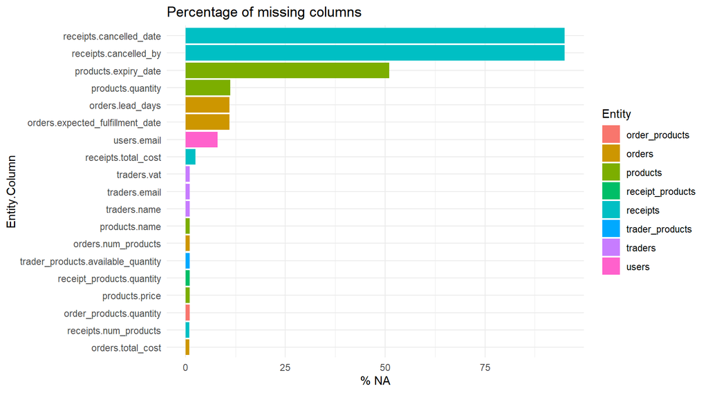

```r
all_entities <- list(
  users = users, traders = traders, products = products,
  orders = orders, receipts = receipts,
  order_products = order_products,
  receipt_products = receipt_products,
  trader_products = trader_products
)

missing_summary <- bind_rows(lapply(names(all_entities), function(nm) {
  df <- show_missing_values(all_entities[[nm]])
  df$Entity <- nm
  df$Pct_Missing <- round(100 * df$No_NA / sdf_nrow(all_entities[[nm]]), 2)
  df
}))

missing_summary <- missing_summary %>% filter(No_NA > 0)

ggplot(missing_summary, aes(x = reorder(paste(Entity, Column, sep = "."), Pct_Missing),
                            y = Pct_Missing, fill = Entity)) +
  geom_col() +
  coord_flip() +
  labs(title = "Percentage of missing columns",
       x = "Entity.Column", y = "% NA") +
  theme_minimal()
```

Iz vizualizacije je vidljivo da određene kolone sadrže strukturno opravdane nedostajuće vrijednosti – npr. `cancelled_date` i `cancelled_by` koji su prazni za narudžbine koje nisu otkazane, kao i `expiry_date` za proizvode bez roka trajanja. Ovakve slučajeve treba tretirati semantičkim popunjavanjem, a ne uklanjanjem redova.

# 4 Čišćenje i priprema podataka

## 4.1 Strategija čišćenja

Primijenjena je adaptivna strategija koja razlikuje dvije kategorije nedostajućih vrijednosti:

- **Kolone sa manje od 15% nedostajućih vrijednosti**: Redovi sa nedostajućim vrijednostima se uklanjaju. Gubitak podataka je prihvatljiv s obzirom na mali udio.
- **Kolone sa 15% ili više nedostajućih vrijednosti**: Vrijednosti se popunjavaju prema tipu kolone – kategoričke kolone se popunjavaju semantički smislenim labelama (“Not Cancelled”, “No Expiry Date”, “Unknown”), dok se numeričke kolone popunjavaju medijanom (robusna mjera centralne tendencije otporna na ekstremne vrijednosti).

Ova strategija čuva što veći broj redova, istovremeno osiguravajući konzistentnost podataka neophodnu za modelovanje.

```r
clean_data <- function(spark_df, df_name) {
  na_table <- spark_df %>%
    summarise(across(everything(), ~sum(as.integer(is.na(.))))) %>%
    collect()

  total_rows <- sdf_nrow(spark_df)
  if (total_rows == 0) return(spark_df)

  na_summary <- data.frame(
    Column = colnames(na_table),
    No_NA = as.numeric(na_table[1,]),
    Pct_Missing = round(100 * as.numeric(na_table[1,]) / total_rows, 2)
  )

  cols_to_drop <- na_summary %>%
    filter(Pct_Missing > 0 & Pct_Missing < 15) %>%
    pull(Column)
  cols_to_fill <- na_summary %>%
    filter(Pct_Missing >= 15) %>%
    pull(Column)

  cleaned_df <- spark_df
  col_types <- sdf_schema(cleaned_df)

  if (length(cols_to_drop) > 0) {
    for (col in cols_to_drop) {
      cleaned_df <- cleaned_df %>% filter(!is.na(!!sym(col)))
    }
  }

  if (length(cols_to_fill) > 0) {
    for (col in cols_to_fill) {
      col_type <- col_types[[col]]$type
      if (col %in% c("cancelled_date", "cancelled_by")) {
        cleaned_df <- cleaned_df %>%
          mutate(!!sym(col) := ifelse(is.na(!!sym(col)), "Not Cancelled", as.character(!!sym(col))))
      } else if (col == "expiry_date") {
        cleaned_df <- cleaned_df %>%
          mutate(!!sym(col) := ifelse(is.na(!!sym(col)), "No Expiry Date", as.character(!!sym(col))))
      } else if (col_type %in% c("DoubleType", "IntegerType", "LongType", "FloatType")) {
        med_val <- cleaned_df %>%
          summarise(m = percentile_approx(!!sym(col), 0.5, na.rm = TRUE)) %>%
          pull(m)
        cleaned_df <- cleaned_df %>%
          mutate(!!sym(col) := ifelse(is.na(!!sym(col)), med_val, !!sym(col)))
      } else if (col_type %in% c("TimestampType", "DateType")) {
        cleaned_df <- cleaned_df
      } else {
        cleaned_df <- cleaned_df %>%
          mutate(!!sym(col) := ifelse(is.na(!!sym(col)), "Unknown", !!sym(col)))
      }
    }
  }

  sdf_persist(cleaned_df, storage.level = "MEMORY_AND_DISK")
}
```

## 4.2 Primjena čišćenja i referentni integritet

Pored samog čišćenja, za svaki zavisni entitet (narudžbine, računi, veze između entiteta) primijenjen je `inner_join` prema roditeljskim entitetima. Na ovaj način se osigurava referentni integritet – u analizi učestvuju isključivo narudžbine sa validnim korisnicima, računi sa validnim narudžbinama i validnim trgovcima itd. Ovo je posebno važno u kontekstu blockchain sistema gdje konzistentnost lanca podataka predstavlja suštinsku pretpostavku.

## 4.3 Rezultati čišćenja

Tabelarni pregled prikazuje broj redova prije i poslije čišćenja za svaki entitet, kao i procenat zadržanih zapisa.

```r
users_cleaned <- clean_data(users, "users")
traders_cleaned <- clean_data(traders, "traders")
products_cleaned <- clean_data(products, "products")

orders_cleaned <- clean_data(orders, "orders") %>%
  inner_join(users_cleaned %>% select(id), by = c("user_id" = "id")) %>%
  sdf_persist(storage.level = "MEMORY_AND_DISK")

receipts_cleaned <- clean_data(receipts, "receipts") %>%
  inner_join(orders_cleaned %>% select(id), by = c("order_id" = "id")) %>%
  inner_join(traders_cleaned %>% select(id), by = c("trader_id" = "id")) %>%
  inner_join(users_cleaned %>% select(id), by = c("user_id" = "id")) %>%
  sdf_persist(storage.level = "MEMORY_AND_DISK")

order_products_cleaned <- clean_data(order_products, "order_products") %>%
  inner_join(orders_cleaned %>% select(id), by = c("order_id" = "id")) %>%
  inner_join(products_cleaned %>% select(id), by = c("product_id" = "id")) %>%
  sdf_persist(storage.level = "MEMORY_AND_DISK")

receipt_products_cleaned <- clean_data(receipt_products, "receipt_products") %>%
  inner_join(receipts_cleaned %>% select(id), by = c("receipt_id" = "id")) %>%
  inner_join(products_cleaned %>% select(id), by = c("product_id" = "id")) %>%
  sdf_persist(storage.level = "MEMORY_AND_DISK")

trader_products_cleaned <- clean_data(trader_products, "trader_products") %>%
  inner_join(traders_cleaned %>% select(id), by = c("trader_id" = "id")) %>%
  inner_join(products_cleaned %>% select(id), by = c("product_id" = "id")) %>%
  sdf_persist(storage.level = "MEMORY_AND_DISK")

for (nm in c("users", "traders", "products", "orders", "receipts",
             "order_products", "receipt_products", "trader_products")) {
  orig <- get(nm)
  cleaned <- get(paste0(nm, "_cleaned"))
  cat(sprintf("%-20s %10d -> %10d rows (%.2f%% retained)\n",
              nm, sdf_nrow(orig), sdf_nrow(cleaned),
              100 * sdf_nrow(cleaned) / sdf_nrow(orig)))
}
```

```
## users                    500000 ->     460078 rows (92.02% retained)
## traders                   70000 ->      67822 rows (96.89% retained)
## products                 600000 ->     522304 rows (87.05% retained)
## orders                  2500000 ->    2007549 rows (80.30% retained)
## receipts                2500000 ->    1878385 rows (75.14% retained)
## order_products          9904844 ->    6894825 rows (69.61% retained)
## receipt_products        7501147 ->    4908030 rows (65.43% retained)
## trader_products         7498428 ->    6263697 rows (83.53% retained)
```

# 5 Analiza podataka

## 5.1 Analiza atributa po entitetima

Analiza je sprovedena sistematski, primjenom funkcija prilagođenih tipu podataka svake kolone:

- **Booleanske kolone**: Prikaz frekvencija i procenta pojave vrijednosti `TRUE`/`FALSE`.
- **Kategoričke kolone (String)**: Distribucija top-N najčešćih vrijednosti sa procentualnim učešćem; za kolone tipa ID provjerava se jedinstvenost i dupliciranost.
- **Numeričke kolone**: Deskriptivna statistika (min, max, srednja vrijednost, standardna devijacija, medijan, kvartili), histogram distribucije i boxplot.
- **Vremenske kolone (Timestamp)**: Raspon vrijednosti i trend broja zapisa po kalendarskim mjesecima.

```r
analyze_boolean <- function(spark_df, col_name) {
  total_rows <- sdf_nrow(spark_df)

  counts_df <- spark_df %>%
    group_by(!!sym(col_name)) %>%
    summarise(Frequency = n()) %>%
    collect()

  counts_df$Pct <- round(100 * counts_df$Frequency / total_rows, 2)

  colnames(counts_df)[1] <- "Value"

  p <- ggplot(counts_df, aes(x = factor(Value), y = Pct, fill = factor(Value))) +
    geom_col() +
    geom_text(aes(label = paste0(Pct, "%")), vjust = -0.3) +
    labs(title = paste("orders_cleaned -", col_name),
         x = col_name,
         y = "Percentage (%)") +
    theme_minimal() +
    theme(legend.position = "none")

  print(p)

  print(counts_df)

  counts_df
}

analyze_string <- function(spark_df, col_name, top_n = 5, is_id_like = FALSE) {
  total_rows <- sdf_nrow(spark_df)

  cardinality <- spark_df %>%
    summarise(n_distinct = n_distinct(!!sym(col_name))) %>%
    pull(n_distinct)

  top_n_df <- spark_df %>%
    group_by(!!sym(col_name)) %>%
    summarise(Frequency = n()) %>%
    arrange(desc(Frequency)) %>%
    head(top_n) %>%
    collect()

  top_n_df$Pct_Of_Total <- round(100 * top_n_df$Frequency / total_rows, 2)
  colnames(top_n_df)[1] <- "Value"

  print(top_n_df)

  if (is_id_like) {
    duplicates <- total_rows - cardinality

    dup_examples <- spark_df %>%
      group_by(!!sym(col_name)) %>%
      summarise(Count = n()) %>%
      filter(Count > 1) %>%
      arrange(desc(Count)) %>%
      head(5) %>%
      collect()

    print(dup_examples)
  }
  should_plot <- !is_id_like && sum(top_n_df$Pct_Of_Total) >= 1

  if (should_plot) {
    p <- ggplot(top_n_df, aes(x = reorder(Value, Frequency), y = Pct_Of_Total)) +
      geom_col(fill = "steelblue") +
      geom_text(aes(label = paste0(Pct_Of_Total, "%")), hjust = -0.1) +
      coord_flip() +
      labs(title = paste("Top", top_n, "-", col_name),
           x = col_name, y = "Percentage (%)") +
      theme_minimal()

    print(p)
  }

  invisible(list(cardinality = cardinality, top_n = top_n_df))
}

analyze_numeric <- function(spark_df, col_name) {
  minimum <- spark_df %>%
    summarise(min_value = min(!!sym(col_name), na.rm = TRUE)) %>%
    collect()

  maximum <- spark_df %>%
    summarise(max_value = max(!!sym(col_name), na.rm = TRUE)) %>%
    collect()

  median <- spark_df %>%
    summarise(mean_value = mean(!!sym(col_name), na.rm = TRUE)) %>%
    collect()

  average <- spark_df %>%
    summarise(avg_value = average(!!sym(col_name), na.rm = TRUE)) %>%
    collect()

  quantile <- spark_df %>%
    summarise(qua_value = quantile(!!sym(col_name), na.rm = TRUE)) %>%
    collect()

  print(minimum, maximum, median, average, quantile)
}

analyze_numeric <- function(spark_df, col_name) {
  stats <- spark_df %>%
    summarise(
      Min = min(!!sym(col_name)),
      Max = max(!!sym(col_name)),
      Average = mean(!!sym(col_name)),
      Std_Dev = sd(!!sym(col_name)),

      Median = percentile_approx(!!sym(col_name), 0.5),

      Quantile_25 = percentile_approx(!!sym(col_name), 0.25),
      Quantile_75 = percentile_approx(!!sym(col_name), 0.75)
    ) %>%
    collect()

  data <- data.frame(
    Metrics = colnames(stats),
    Value = as.numeric(stats[1,])
  )

  if (is.finite(stats$Min[1]) &&
    is.finite(stats$Max[1]) &&
    stats$Max[1] > stats$Min[1]) {
    n_bins <- 30
    splits <- seq(stats$Min[1], stats$Max[1], length.out = n_bins + 1)
    splits[1] <- -Inf
    splits[length(splits)] <- Inf

    binned <- spark_df %>%
      filter(!is.na(!!sym(col_name))) %>%
      ft_bucketizer(input_col = col_name, output_col = "bucket", splits = splits) %>%
      group_by(bucket) %>%
      summarise(count = n()) %>%
      collect() %>%
      arrange(bucket)

    binned$bin_center <- (splits[binned$bucket + 1] + splits[binned$bucket + 2]) / 2
    binned$bin_center[binned$bucket == 0] <- stats$Min[1]
    binned$bin_center[binned$bucket == n_bins - 1] <- stats$Max[1]

    p_hist <- ggplot(binned, aes(x = bin_center, y = count)) +
      geom_col(fill = "steelblue", width = (stats$Max[1] - stats$Min[1]) / n_bins * 0.9) +
      labs(title = paste("Distribucija -", col_name),
           x = col_name, y = "Broj zapisa") +
      theme_minimal()

    print(p_hist)
  }

  box_df <- data.frame(
    x = col_name,
    ymin = stats$Min[1],
    lower = stats$Quantile_25[1],
    middle = stats$Median[1],
    upper = stats$Quantile_75[1],
    ymax = stats$Max[1]
  )

  p_box <- ggplot(box_df, aes(x = x)) +
    geom_boxplot(aes(ymin = ymin, lower = lower, middle = middle, upper = upper, ymax = ymax),
                 stat = "identity", fill = "lightblue") +
    labs(title = paste("Boxplot -", col_name), x = "", y = col_name) +
    theme_minimal()

  print(p_box)

  print(data)
}

analyze_timestamp <- function(spark_df, col_name) {
  stats <- spark_df %>%
    summarise(
      Min = min(!!sym(col_name), na.rm = TRUE),
      Max = max(!!sym(col_name), na.rm = TRUE)
    ) %>%
    collect()

  min_date <- stats$Min[1]
  max_date <- stats$Max[1]
  day_span <- as.numeric(difftime(max_date, min_date, units = "days"))

  data <- data.frame(
    Metrics = c("Min", "Max", "Span (days)"),
    Value = c(as.character(min_date), as.character(max_date), round(day_span, 1))
  )

  monthly <- spark_df %>%
    filter(!is.na(!!sym(col_name))) %>%
    mutate(year_month = date_format(!!sym(col_name), "yyyy-MM")) %>%
    group_by(year_month) %>%
    summarise(count = n()) %>%
    arrange(year_month) %>%
    collect()

  p <- ggplot(monthly, aes(x = year_month, y = count, group = 1)) +
    geom_line(color = "steelblue") +
    geom_point(color = "steelblue") +
    labs(title = paste("Broj zapisa po mesecu -", col_name),
         x = "Godina-Mesec", y = "Broj zapisa") +
    theme_minimal() +
    theme(axis.text.x = element_text(angle = 90, hjust = 1))

  print(p)

  print(data)

  invisible(list(min = min_date, max = max_date, range_days = day_span))
}

analyze_and_visualize <- function(data) {
  cols <- sdf_schema(data)
  for (col in cols) {
    cat("Name: ", col[[1]], "\t", "Type: ", col[[2]], "\n")
    if (col[[2]] == "BooleanType") {
      plot_df <- analyze_boolean(data, col[[1]])
    } else if (col[[2]] == "StringType") {
      is_id <- grepl("id", col[[1]], ignore.case = TRUE)
      analyze_string(data, col[[1]], top_n = 5, is_id_like = is_id)
    } else if (col[[2]] == "DoubleType" ||
      col[[2]] == "IntegerType" ||
      col[[2]] == "LongType") {
      analyze_numeric(data, col[[1]])
    } else if (col[[2]] == "TimestampType") {
      analyze_timestamp(data, col[[1]])
    }
  }
}
```

```r
analyze_and_visualize(users_cleaned)
```

```
## Name:  doc_type   Type:  StringType
## # A tibble: 1 × 3
##   Value Frequency Pct_Of_Total
##   <chr>     <dbl>        <dbl>
## 1 user     460078          100
```

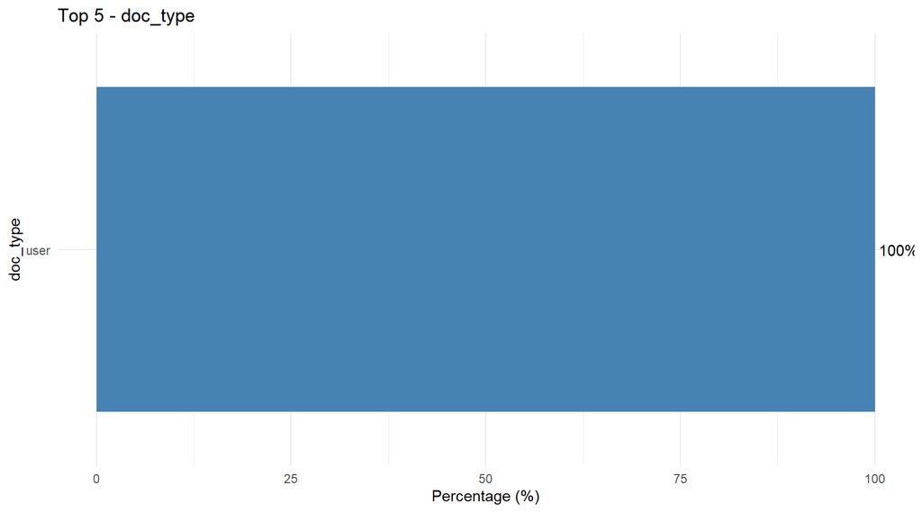

```
## Name:  id     Type:  StringType
## # A tibble: 5 × 3
##   Value                                Frequency Pct_Of_Total
##   <chr>                                    <dbl>        <dbl>
## 1 0ff0c2d2-0f4c-420d-9869-a25b1ae9b45c         1            0
## 2 10653e7c-b6c6-4609-8de0-ab69e6136e3b         1            0
## 3 fad9885e-f3cb-4ce5-95b3-ac4c24815c07         1            0
## 4 fe0e14ae-1f96-4920-a887-55746cf7d7b7         1            0
## 5 61c0a924-ed54-4abe-a5b1-2ba8d8c460a3         1            0
## # A tibble: 0 × 2
## # ℹ 2 variables: id <chr>, Count <dbl>
## Name:  name   Type:  StringType
## # A tibble: 5 × 3
##   Value   Frequency Pct_Of_Total
##   <chr>       <dbl>        <dbl>
## 1 Radosav      1245         0.27
## 2 Filip        1237         0.27
## 3 Aleksa       1235         0.27
## 4 Ana          1227         0.27
## 5 Ina          1224         0.27
```

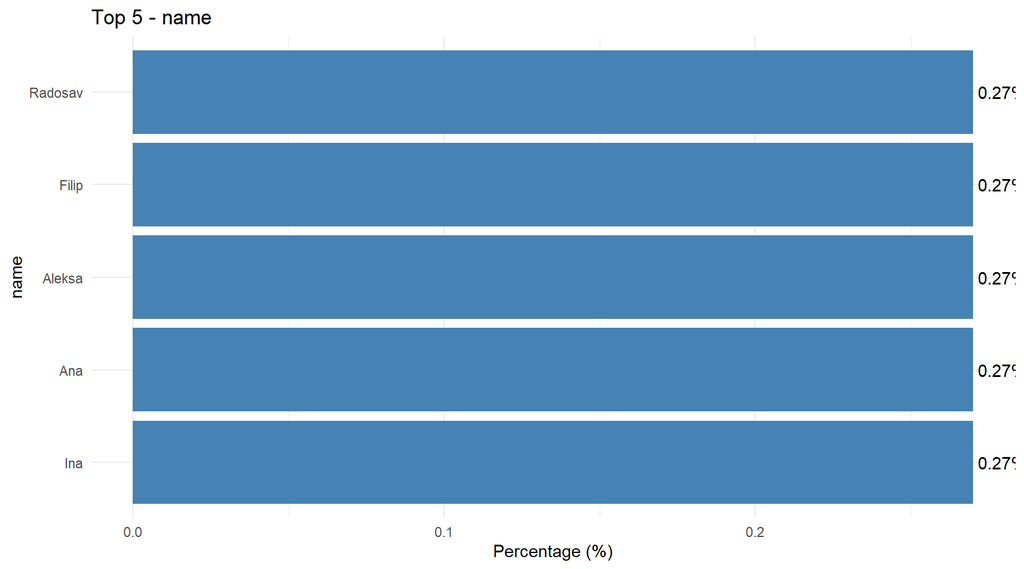

```
## Name:  surname    Type:  StringType
## # A tibble: 5 × 3
##   Value       Frequency Pct_Of_Total
##   <chr>           <dbl>        <dbl>
## 1 Manastirlić       508         0.11
## 2 Ičelić            494         0.11
## 3 Bjeličić          494         0.11
## 4 Jelašić           488         0.11
## 5 Vučo              487         0.11
## Name:  email      Type:  StringType
## # A tibble: 5 × 3
##   Value                  Frequency Pct_Of_Total
##   <chr>                      <dbl>        <dbl>
## 1 Simonida70@hotmail.com         9            0
## 2 Vasil18@hotmail.com            8            0
## 3 Svetislav43@gmail.com          8            0
## 4 Anka95@hotmail.com             8            0
## 5 Velimir21@gmail.com            7            0
## Name:  deleted    Type:  BooleanType
```

[figure not shown]

```
## # A tibble: 2 × 3
##   Value Frequency   Pct
##   <lgl>     <dbl> <dbl>
## 1 TRUE      22887  4.97
## 2 FALSE    437191 95.0
```

```r
analyze_and_visualize(traders_cleaned)
```

```
## Name:  doc_type   Type:  StringType
## # A tibble: 1 × 3
##   Value  Frequency Pct_Of_Total
##   <chr>      <dbl>        <dbl>
## 1 trader     67822          100
```

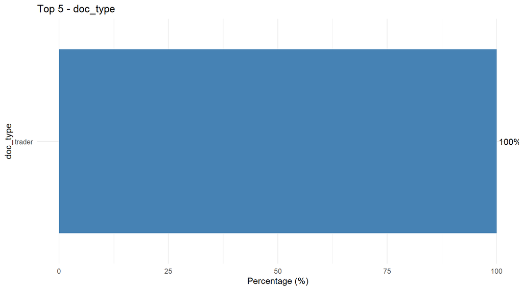

```
## Name:  id     Type:  StringType
## # A tibble: 5 × 3
##   Value                                Frequency Pct_Of_Total
##   <chr>                                    <dbl>        <dbl>
## 1 1cb6d4cd-e099-49ab-8b12-f6d1fe54ead3         1            0
## 2 f823df89-c288-40f7-b481-3a020b164bfa         1            0
## 3 5c151fc7-c017-41cf-a626-47cf06cfbd04         1            0
## 4 31899a50-393a-4bff-8a53-44445fdca2ae         1            0
## 5 aaf0bf5e-f374-4bc9-861a-b68b0bf7e18c         1            0
## # A tibble: 0 × 2
## # ℹ 2 variables: id <chr>, Count <dbl>
## Name:  name   Type:  StringType
## # A tibble: 5 × 3
##   Value          Frequency Pct_Of_Total
##   <chr>              <dbl>        <dbl>
## 1 Repac and Sons        16         0.02
## 2 Ilić Group            14         0.02
## 3 Kuželj Inc            14         0.02
## 4 Suša and Sons         14         0.02
## 5 Komarčević Inc        14         0.02
## Name:  email      Type:  StringType
## # A tibble: 5 × 3
##   Value               Frequency Pct_Of_Total
##   <chr>                   <dbl>        <dbl>
## 1 Bojan7@yahoo.com            4         0.01
## 2 Rados46@hotmail.com         4         0.01
## 3 Teona80@gmail.com           4         0.01
## 4 Milutin61@gmail.com         4         0.01
## 5 Sonja17@yahoo.com           3         0
## Name:  trader_type    Type:  StringType
## # A tibble: 4 × 3
##   Value       Frequency Pct_Of_Total
##   <chr>           <dbl>        <dbl>
## 1 SUPERMARKET     17043         25.1
## 2 CARDEALER       17017         25.1
## 3 PHARMACY        16975         25.0
## 4 GROCERY         16787         24.8
```

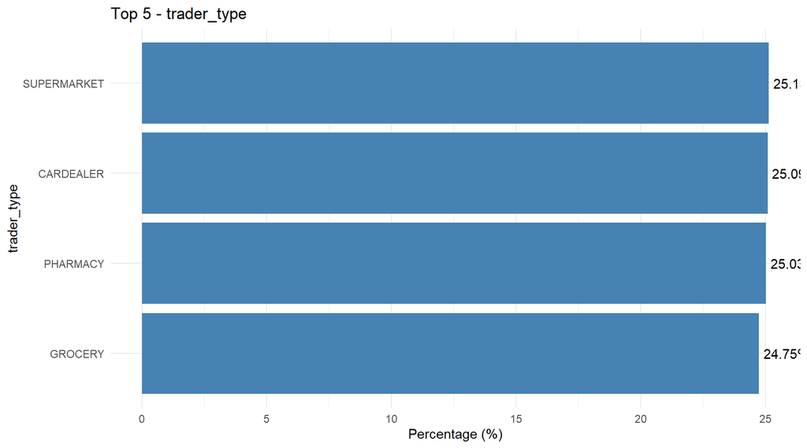

```
## Name:  vat    Type:  StringType
## # A tibble: 5 × 3
##   Value        Frequency Pct_Of_Total
##   <chr>            <dbl>        <dbl>
## 1 VAT_ULMCN9BW         1            0
## 2 VAT_DVXY24PP         1            0
## 3 VAT_37BELSN9         1            0
## 4 VAT_XR9JLI04         1            0
## 5 VAT_BPQ9YGMF         1            0
## Name:  deleted    Type:  BooleanType
```

[figure not shown]

```
## # A tibble: 2 × 3
##   Value Frequency   Pct
##   <lgl>     <dbl> <dbl>
## 1 TRUE       3329  4.91
## 2 FALSE     64493 95.1
```

```r
analyze_and_visualize(products_cleaned)
```

```
## Name:  doc_type   Type:  StringType
## # A tibble: 1 × 3
##   Value   Frequency Pct_Of_Total
##   <chr>       <dbl>        <dbl>
## 1 product    522304          100
```

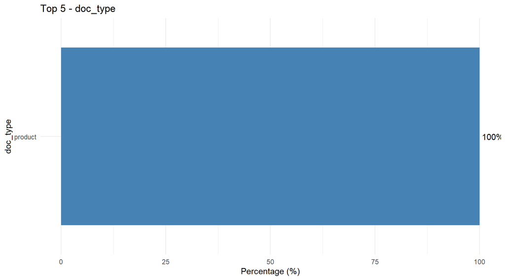

```
## Name:  id     Type:  StringType
## # A tibble: 5 × 3
##   Value                                Frequency Pct_Of_Total
##   <chr>                                    <dbl>        <dbl>
## 1 be83bd5b-dd78-46ad-8c08-4aa40d2d5c2e         1            0
## 2 0134a91c-ab11-4288-8613-e134119d9ed3         1            0
## 3 63de2150-d153-4a1b-b06d-0be8c6b5fa3a         1            0
## 4 2c3be93e-57e3-4409-a08c-9c9d75b03c6b         1            0
## 5 186afd50-4df5-4d7f-8f57-7e99d87b93fb         1            0
## # A tibble: 0 × 2
## # ℹ 2 variables: id <chr>, Count <dbl>
## Name:  name   Type:  StringType
## # A tibble: 5 × 3
##   Value          Frequency Pct_Of_Total
##   <chr>              <dbl>        <dbl>
## 1 Hleb Tasty           687         0.13
## 2 Hleb Handmade        680         0.13
## 3 Sok Awesome          675         0.13
## 4 Hleb Recycled        675         0.13
## 5 Hleb Ergonomic       674         0.13
## Name:  price      Type:  DoubleType
```

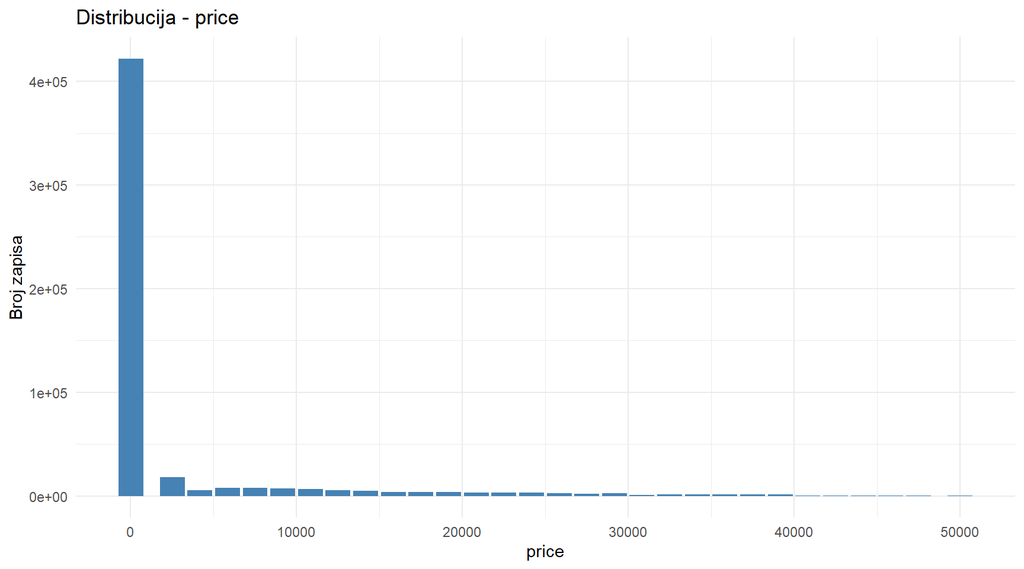

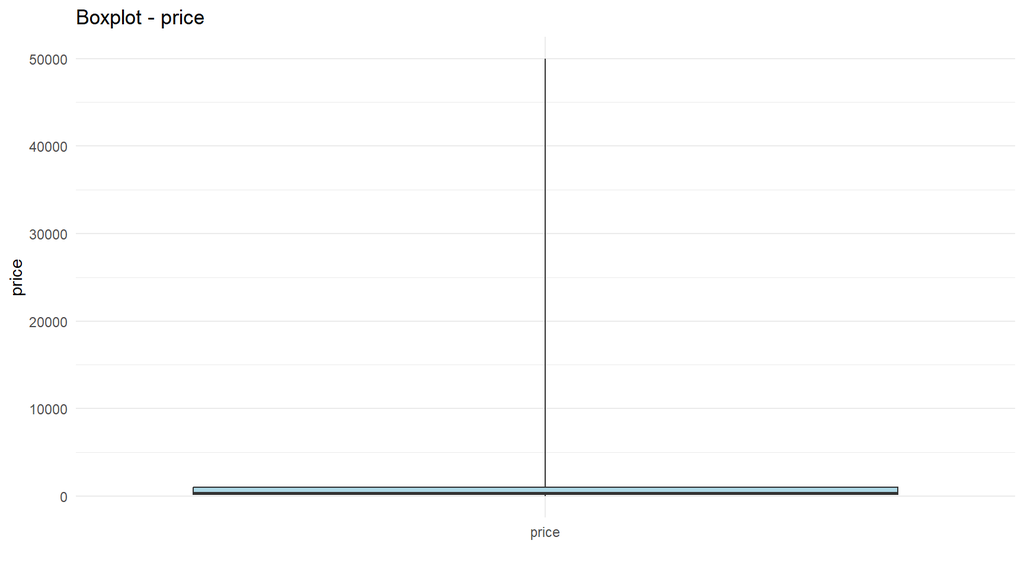

```
##       Metrics     Value
## 1         Min    30.000
## 2         Max 49997.450
## 3     Average  2954.125
## 4     Std_Dev  7082.947
## 5      Median   334.200
## 6 Quantile_25   173.480
## 7 Quantile_75  1040.660
## Name:  quantity   Type:  IntegerType
```

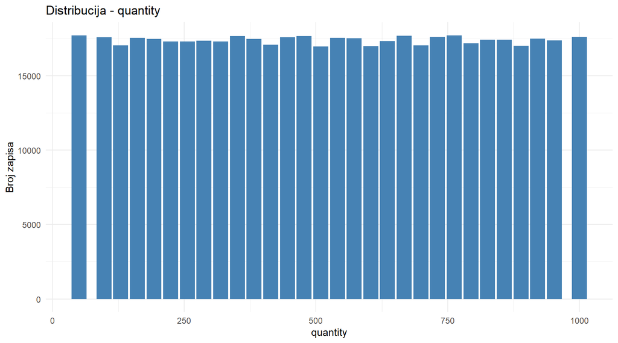

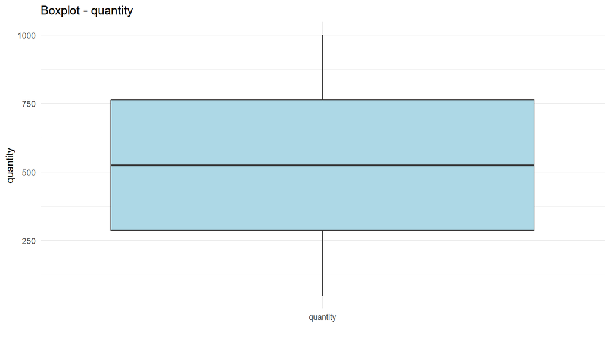

```
##       Metrics     Value
## 1         Min   50.0000
## 2         Max 1000.0000
## 3     Average  524.6353
## 4     Std_Dev  274.5091
## 5      Median  524.0000
## 6 Quantile_25  287.0000
## 7 Quantile_75  762.0000
## Name:  trader_type    Type:  StringType
## # A tibble: 4 × 3
##   Value       Frequency Pct_Of_Total
##   <chr>           <dbl>        <dbl>
## 1 GROCERY        141689         27.1
## 2 SUPERMARKET    141200         27.0
## 3 PHARMACY       140583         26.9
## 4 CARDEALER       98832         18.9
```

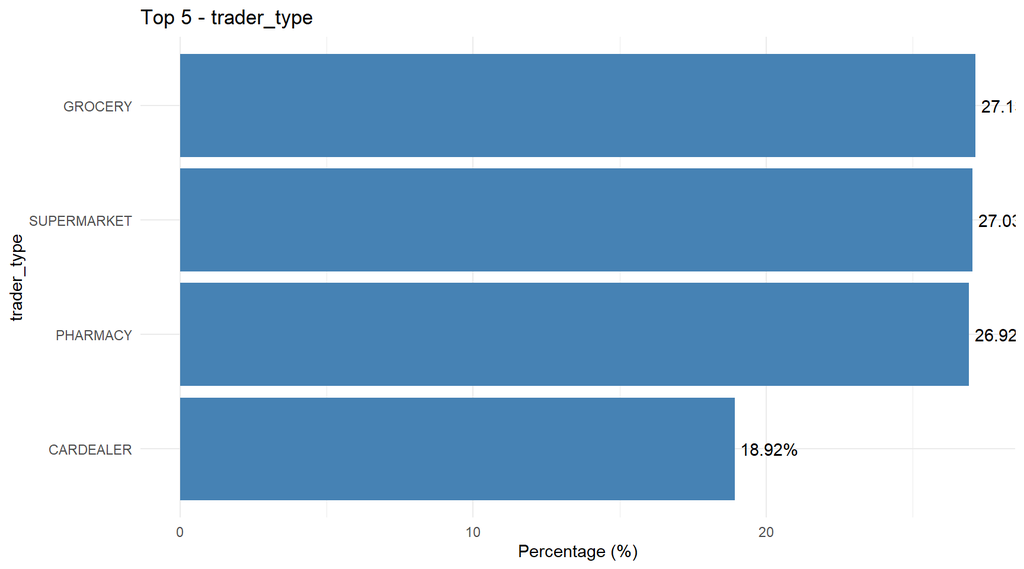

```
## Name:  deleted    Type:  BooleanType
```

[figure not shown]

```
## # A tibble: 2 × 3
##   Value Frequency   Pct
##   <lgl>     <dbl> <dbl>
## 1 TRUE      25941  4.97
## 2 FALSE    496363 95.0
## Name:  expiry_date    Type:  StringType
## # A tibble: 5 × 3
##   Value                   Frequency Pct_Of_Total
##   <chr>                       <dbl>        <dbl>
## 1 No Expiry Date             245840         47.1
## 2 2027-04-18 07:03:00.983         1          0
## 3 2027-07-05 05:58:09.748         1          0
## 4 2026-09-15 14:39:51.71          1          0
## 5 2026-03-24 00:57:25.422         1          0
```

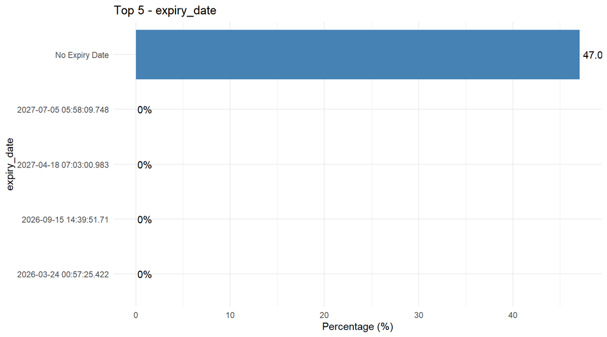

```r
analyze_and_visualize(orders_cleaned)
```

```
## Name:  doc_type   Type:  StringType
## # A tibble: 1 × 3
##   Value Frequency Pct_Of_Total
##   <chr>     <dbl>        <dbl>
## 1 order   2007549          100
```

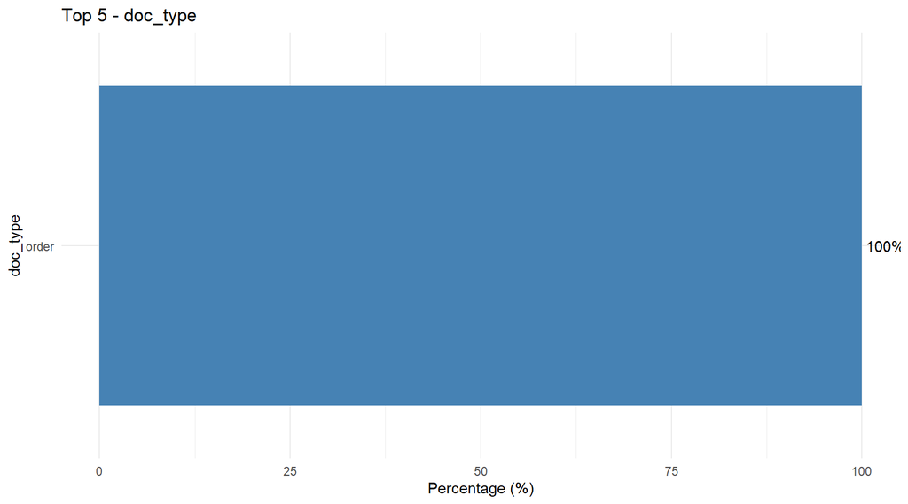

```
## Name:  id     Type:  StringType
## # A tibble: 5 × 3
##   Value                                Frequency Pct_Of_Total
##   <chr>                                    <dbl>        <dbl>
## 1 c168f857-0c17-4540-9dc8-55ada0091bd8         1            0
## 2 15c91d07-e26c-4f9f-9d16-279b69f8618c         1            0
## 3 c516e4b2-34e6-4cfd-9b53-425f16916592         1            0
## 4 99cb71a9-6556-4c56-b45b-1813e329b806         1            0
## 5 11edcd53-4c46-4cac-a6fa-557a58281c65         1            0
## # A tibble: 0 × 2
## # ℹ 2 variables: id <chr>, Count <dbl>
## Name:  user_id    Type:  StringType
## # A tibble: 5 × 3
##   Value                                Frequency Pct_Of_Total
##   <chr>                                    <dbl>        <dbl>
## 1 dc838a15-a862-47e5-a57f-c05d8f8bab28        18            0
## 2 bf11f393-072d-4743-9210-6bcf7c7ff5bf        16            0
## 3 f3781a1f-9ae2-453a-9e31-ce8537be0372        16            0
## 4 0af9e59a-bd16-4ec5-b899-06b501b9ce08        16            0
## 5 eb5dfb98-26e8-463d-a612-153bfe3037cf        16            0
## # A tibble: 5 × 2
##   user_id                              Count
##   <chr>                                <dbl>
## 1 dc838a15-a862-47e5-a57f-c05d8f8bab28    18
## 2 eb5dfb98-26e8-463d-a612-153bfe3037cf    16
## 3 f3877b9d-3d4c-4449-b775-bc7abd420f5f    16
## 4 f3781a1f-9ae2-453a-9e31-ce8537be0372    16
## 5 0af9e59a-bd16-4ec5-b899-06b501b9ce08    16
## Name:  trader_type    Type:  StringType
## # A tibble: 4 × 3
##   Value       Frequency Pct_Of_Total
##   <chr>           <dbl>        <dbl>
## 1 GROCERY        536308         26.7
## 2 SUPERMARKET    525132         26.2
## 3 PHARMACY       510309         25.4
## 4 CARDEALER      435800         21.7
```

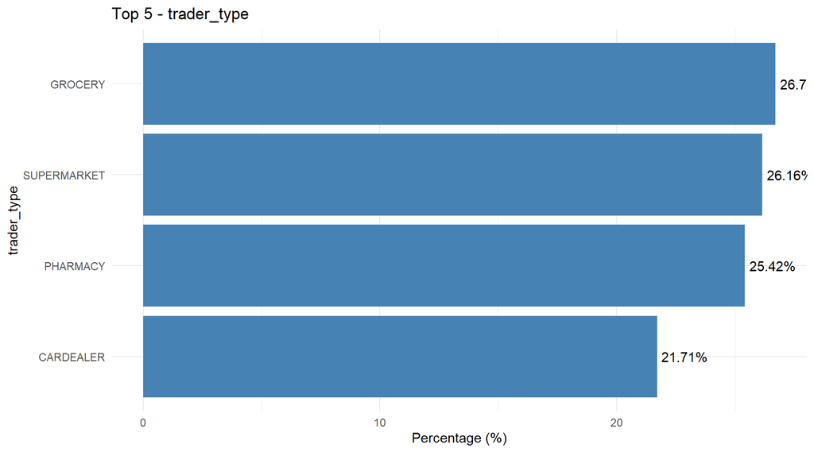

```
## Name:  status     Type:  StringType
## # A tibble: 5 × 3
##   Value     Frequency Pct_Of_Total
##   <chr>         <dbl>        <dbl>
## 1 COMPLETED    685704        34.2
## 2 FULFILLED    466722        23.2
## 3 APPROVED     397064        19.8
## 4 PENDING      286812        14.3
## 5 CANCELLED    171247         8.53
```

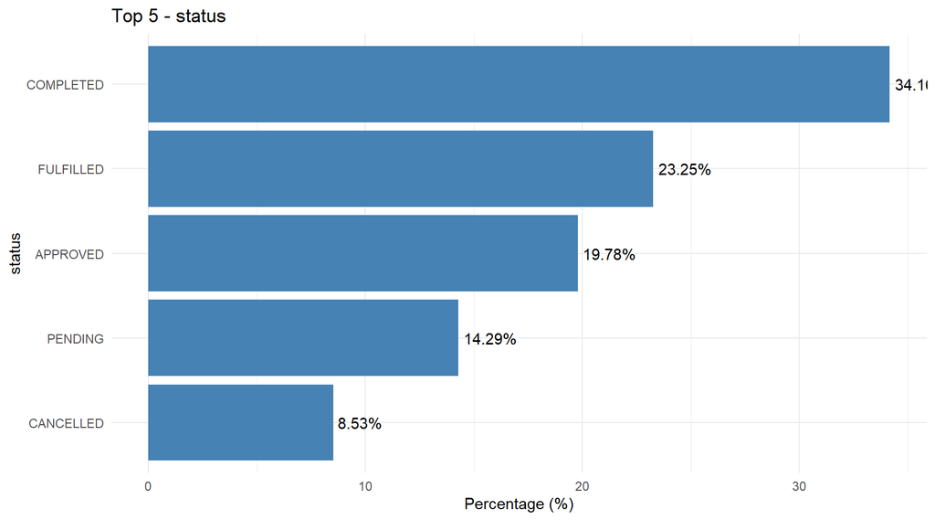

```
## Name:  created_date   Type:  TimestampType
```

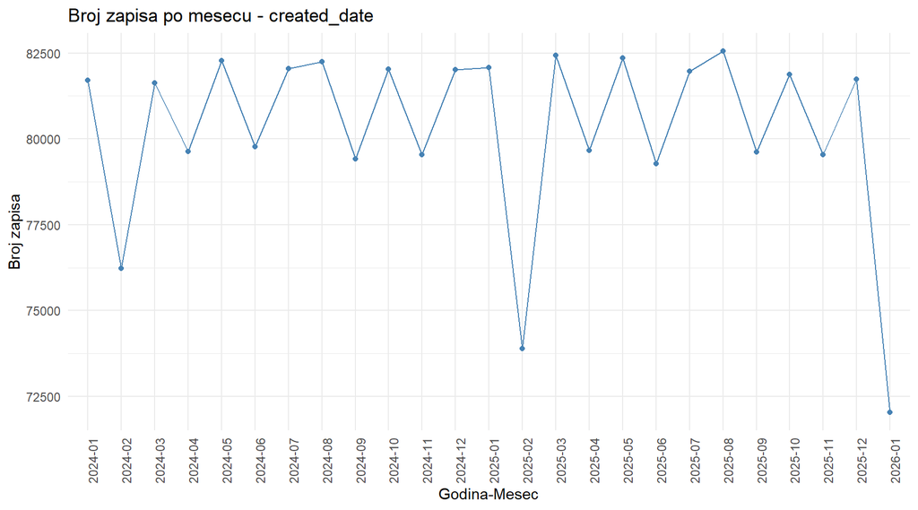

```
##       Metrics                   Value
## 1         Min 2024-01-01 01:00:43.792
## 2         Max 2026-01-28 00:59:22.244
## 3 Span (days)                     758
## Name:  day_of_week    Type:  IntegerType
```

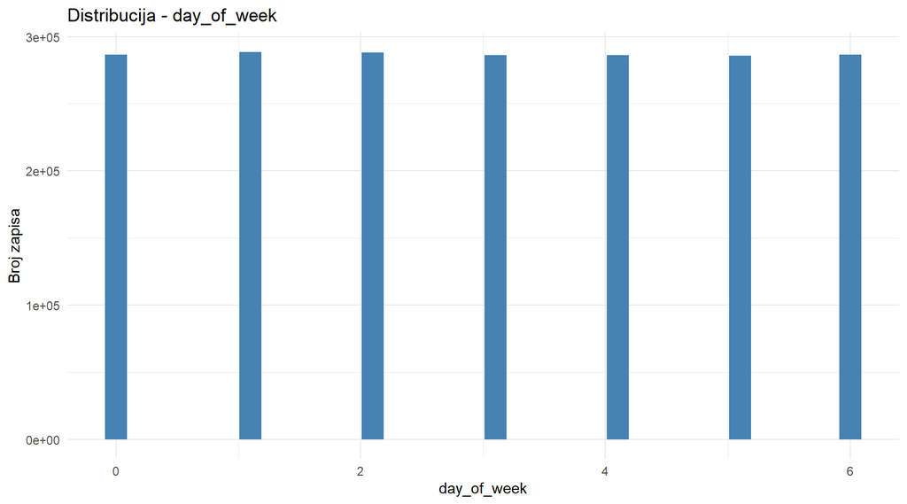

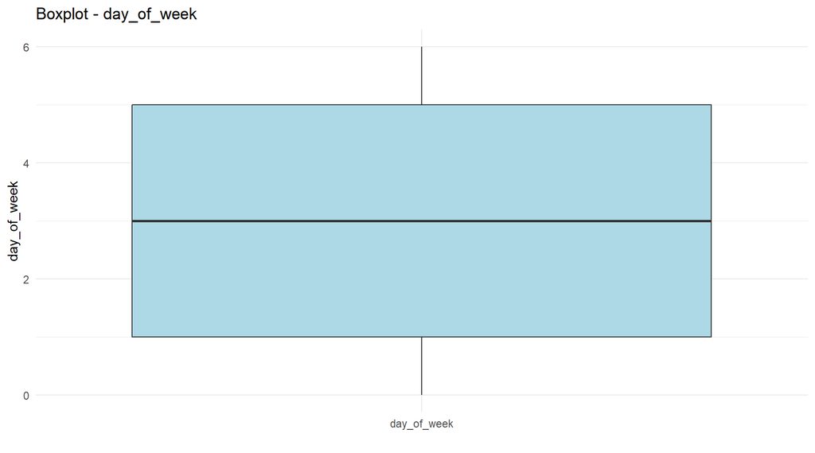

```
##       Metrics    Value
## 1         Min 0.000000
## 2         Max 6.000000
## 3     Average 2.995945
## 4     Std_Dev 1.999484
## 5      Median 3.000000
## 6 Quantile_25 1.000000
## 7 Quantile_75 5.000000
## Name:  month      Type:  IntegerType
```

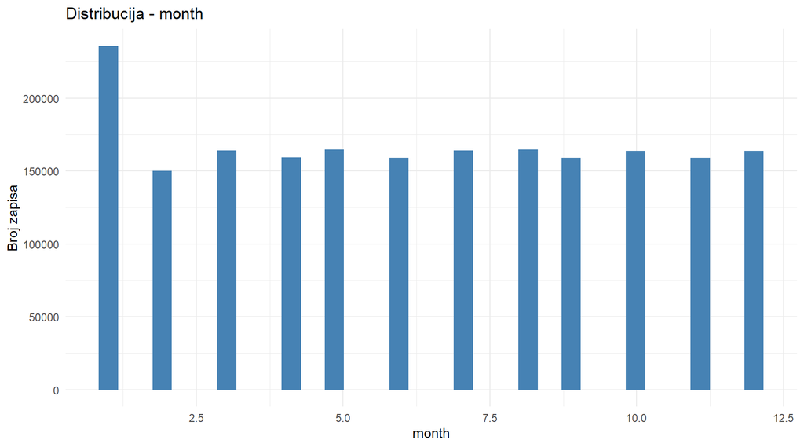

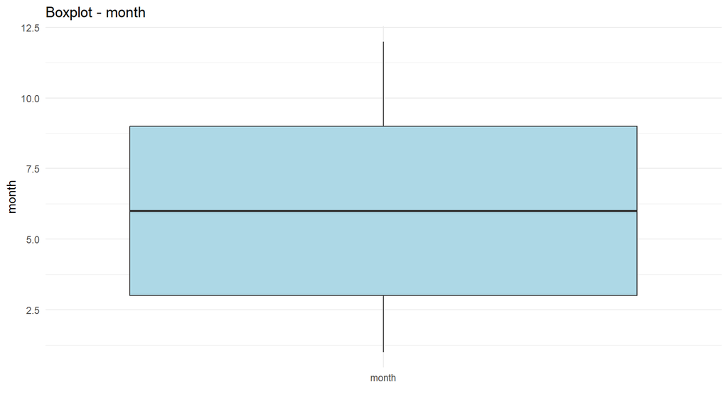

```
##       Metrics     Value
## 1         Min  1.000000
## 2         Max 12.000000
## 3     Average  6.323441
## 4     Std_Dev  3.536917
## 5      Median  6.000000
## 6 Quantile_25  3.000000
## 7 Quantile_75  9.000000
## Name:  quarter    Type:  IntegerType
```

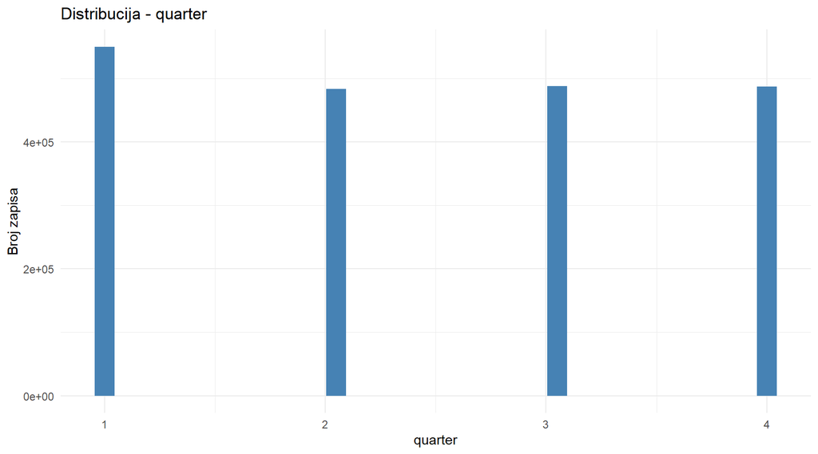

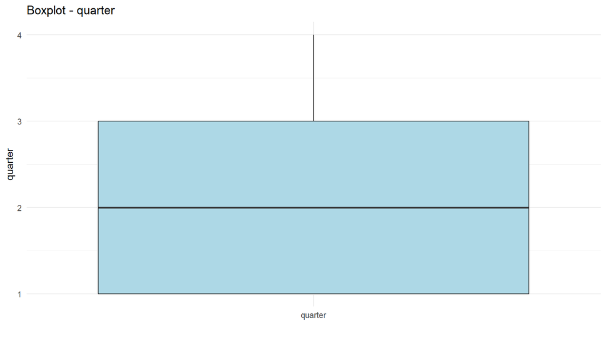

```
##       Metrics    Value
## 1         Min 1.000000
## 2         Max 4.000000
## 3     Average 2.453959
## 4     Std_Dev 1.131671
## 5      Median 2.000000
## 6 Quantile_25 1.000000
## 7 Quantile_75 3.000000
## Name:  expected_fulfillment_date      Type:  TimestampType
```

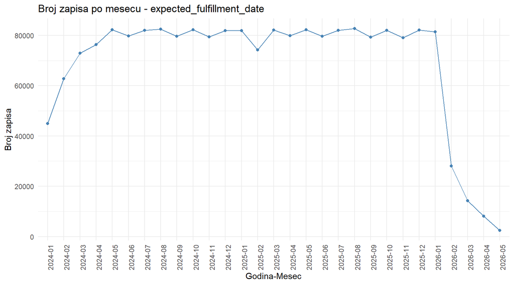

```
##       Metrics                   Value
## 1         Min 2024-01-02 01:00:55.504
## 2         Max 2026-05-28 01:26:14.142
## 3 Span (days)                     877
## Name:  lead_days      Type:  IntegerType
```

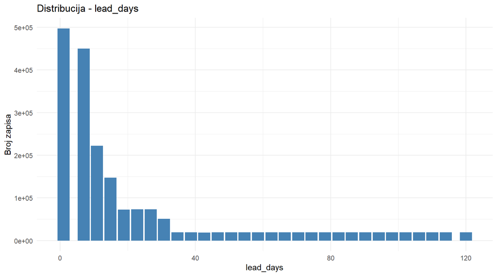

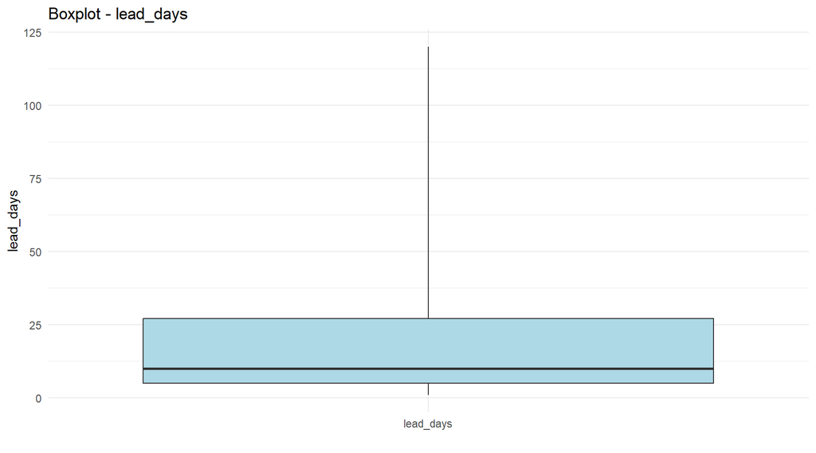

```
##       Metrics     Value
## 1         Min   1.00000
## 2         Max 120.00000
## 3     Average  23.50235
## 4     Std_Dev  30.49671
## 5      Median  10.00000
## 6 Quantile_25   5.00000
## 7 Quantile_75  27.00000
## Name:  num_products   Type:  IntegerType
```